# Proyecto Corto: Explorando Datos de Pacientes en una Clínica

## Programacion Python Basico | ICAI - UNA

## Profesor: Ing. Andrés Mena Abarca

### Nombre del estudiante: Adrian Barboza Chavarría

Link GitHub: https://github.com/abarboza506/Programacion-Python-Basico-GRUPO-1---6181133432/commit/43b7ec956158962f99e71b90f0a0b15c440372c2

¡Bienvenidos al reto STEAM! Hoy serás parte de un equipo de científicos de datos que está desarrollando una aplicación para analizar los datos de los pacientes de una clínica. Este proyecto se integra dentro del enfoque STEAM, donde no solo usaremos habilidades de programación y análisis, sino también creatividad, visualización y reflexión crítica para mejorar la experiencia de salud.

En este reto, utilizaremos **Python** para analizar datos clínicos reales y responder preguntas importantes sobre la salud de los pacientes. También diseñarás soluciones creativas y colaborarás con tus compañeros para mejorar la aplicación.

### Contexto:

El director de la clínica te ha encargado que construyas un sistema que pueda analizar la información de los pacientes, entender las enfermedades tratadas, los medicamentos recetados y comparar pacientes.

### Objetivos del Reto:

1. Aplicar estructuras básicas de Python como listas y ciclos.
2. Leer datos desde un archivo JSON y almacenarlos en listas.
3. Realizar análisis de datos sobre enfermedades y medicamentos.
4. Visualizar y comunicar los resultados de manera creativa.

### Fase Creativa STEAM:

- **Ciencia y Tecnología:** Analizarás los datos clínicos.
- **Ingeniería:** Implementarás las soluciones utilizando estructuras de Python.
- **Arte y Matemáticas:** Visualizarás los resultados de manera atractiva y clara.

¡Comencemos!

## Cargar y Leer los Datos de Pacientes

```python
import json

with open('clinica_intermedio.json', encoding='utf-8') as archivo:
    datos_pacientes = json.load(archivo)

for listas in datos_pacientes:
    print(listas)
```

```
['116640019', 61727979, 'San José', 'Desamparados', 'gripe', 'acetaminofen']
['603240305', 60534319, 'Heredia', 'Santo Domingo', 'gastritis', 'antiácido']
['503980535', 70713699, 'Alajuela', 'San Carlos', 'tos', 'jarabe']
['702370234', 70693575, 'Cartago', 'Paraíso', 'migraña', 'acetaminofen']
['116310912', 88070036, 'San José', 'Curridabat', 'dolor', 'acetaminofen']
['604830325', 83155658, 'Puntarenas', 'Osa', 'gripe', 'acetaminofen']
['116130052', 64069212, 'Guanacaste', 'Liberia', 'gastritis', 'antiácido']
['111860150', 88447416, 'Limón', 'Puerto Viejo', 'diabetes', 'insulina']
['110283', 61088556, 'San José', 'Escazú', 'asma', 'salbutamol']
['503810832', 83076969, 'Heredia', 'Barva', 'gripe', 'acetaminofen']
['114740407', 70112487, 'Cartago', 'Turrialba', 'hipotiroidismo', 'levotiroxina']
['205750691', 83349456, 'San José', 'Montes de Oca', 'alergias', 'loratadina']
['215487963', 78823654, 'Guanacaste', 'Nicoya', 'migraña', 'acetaminofen']
['318540762', 65892345, 'Alajuela', 'Grecia', 'presión alta', 'amlodipino']
['457821904', 72908475, 'Cartago', 'Oreamuno', 'dolor de espalda', 'ibuprofeno']
['602948176', 61928374, 'Heredia', 'Belén', 'ansiedad', 'clonazepam']
['703219485', 63487294, 'Limón', 'Guápiles', 'diabetes', 'insulina']
['825613092', 72845312, 'Puntarenas', 'Coto Brus', 'asma', 'salbutamol']
['908124753', 71239485, 'San José', 'Moravia', 'alergias', 'cetirizina']
['103927564', 63749562, 'Heredia', 'San Isidro', 'gastritis', 'omeprazol']
['200145879', 78546932, 'Guanacaste', 'Santa Cruz', 'presión alta', 'losartán']
['305946278', 65849371, 'Puntarenas', 'Golfito', 'tos', 'jarabe']
['412598764', 73284956, 'San José', 'Tibás', 'dolor de espalda', 'paracetamol']
['507812394', 69231875, 'Cartago', 'El Guarco', 'ansiedad', 'diazepam']
['602938574', 61249375, 'Limón', 'Siquirres', 'diabetes', 'metformina']
['715498372', 74938261, 'Alajuela', 'Atenas', 'asma', 'fluticasona']
['823654091', 69829375, 'San José', 'Pérez Zeledón', 'alergias', 'loratadina']
['912475683', 73485629, 'Cartago', 'Jiménez', 'hipotiroidismo', 'levotiroxina']
['104598273', 68597312, 'Heredia', 'San Rafael', 'gripe', 'acetaminofen']
['205963184', 71928364, 'Puntarenas', 'Esparza', 'gastritis', 'pantoprazol']
['301456897', 64395721, 'San José', 'Alajuelita', 'migraña', 'ibuprofeno']
['401598723', 71928574, 'Limón', 'Matina', 'presión alta', 'enalapril']
['510298374', 62938475, 'Guanacaste', 'Bagaces', 'asma', 'salbutamol']
['621095837', 75928346, 'Cartago', 'Turrialba', 'diabetes', 'insulina']
['732145609', 68495731, 'Heredia', 'Flores', 'dolor', 'acetaminofen']
['802149357', 72938475, 'San José', 'Goicoechea', 'gastritis', 'omeprazol']
['913256748', 65849371, 'Puntarenas', 'Buenos Aires', 'presión alta', 'amlodipino']
['102548397', 67293857, 'Limón', 'Talamanca', 'asma', 'salbutamol']
['204985763', 74583925, 'Guanacaste', 'Carrillo', 'gripe', 'acetaminofen']
```

## Desafío 1: Análisis Científico - Reporte de Enfermedades Tratadas

Tu primer reto es analizar los datos de los pacientes para generar un reporte de las enfermedades tratadas en la clínica. Utiliza listas y ciclos para contar cuántos pacientes han sido tratados por cada enfermedad.

### Instrucciones:

1. Crea una lista vacía donde almacenarás las enfermedades.
2. Recorre los datos de los pacientes y extrae la enfermedad de cada paciente.
3. Cuenta cuántos pacientes han sido tratados por cada enfermedad.
4. Visualiza los resultados de manera clara utilizando la técnica que elijas (gráficos o tablas).

### Preguntas:

- ¿Qué enfermedades son las más tratadas en la clínica?
- ¿Hay alguna enfermedad que te sorprenda por su prevalencia?

### **Paso a Paso para el Estudiante**

#### **Paso 1: Crear las Listas**

1. **Objetivo:** Necesitamos dos listas para almacenar:
   - Los nombres de las enfermedades.
   - La cantidad de veces que cada i aparece.
2. **Instrucción:**
   - Crea una lista vacía llamada `lista_enfermedades`.
   - Crea otra lista vacía llamada `lista_cantidades`.

```python
# Lista para almacenar las enfermedades y sus cantidades

lista_enfermedades = []
lista_cantidades = []
```

#### **Paso 2: Recorrer los Datos de los Pacientes**

1. **Objetivo:** Vamos a analizar cada paciente para extraer su enfermedad.
2. **Instrucción:**
   - Usa un bucle `for` para recorrer cada `paciente` en `datos_pacientes` (ya está definida en el código como una lista de listas).
   - Dentro del bucle, asigna la enfermedad del paciente (índice `4` de cada lista) a una variable llamada `enfermedad`.

#### Índices y elementos de las listas

| Elemento | Índice |
| --- | --- |
| Identificación | 0 |
| Teléfono | 1 |
| Provincia | 2 |
| Cantón | 3 |
| Enfermedad | 4 |
| Medicamento | 5 |

```python
# Extraemos la enfermedad del paciente
# Puedes imprimir el for para ver los datos que se procesan

for listas in datos_pacientes:
    print(listas[4])
```

```
gripe
gastritis
tos
migraña
dolor
gripe
gastritis
diabetes
asma
gripe
hipotiroidismo
alergias
migraña
presión alta
dolor de espalda
ansiedad
diabetes
asma
alergias
gastritis
presión alta
tos
dolor de espalda
ansiedad
diabetes
asma
alergias
hipotiroidismo
gripe
gastritis
migraña
presión alta
asma
diabetes
dolor
gastritis
presión alta
asma
gripe
```

```python
# Almacenar datos en la lista 'enfermedad'

enfermedad = []

for listas in datos_pacientes:
    enfermedad.append(listas[4])

for l_enfermedad in enfermedad:
    print(l_enfermedad)

print(enfermedad)
```

```
gripe
gastritis
tos
migraña
dolor
gripe
gastritis
diabetes
asma
gripe
hipotiroidismo
alergias
migraña
presión alta
dolor de espalda
ansiedad
diabetes
asma
alergias
gastritis
presión alta
tos
dolor de espalda
ansiedad
diabetes
asma
alergias
hipotiroidismo
gripe
gastritis
migraña
presión alta
asma
diabetes
dolor
gastritis
presión alta
asma
gripe
['gripe', 'gastritis', 'tos', 'migraña', 'dolor', 'gripe', 'gastritis', 'diabetes', 'asma', 'gripe', 'hipotiroidismo', 'alergias', 'migraña', 'presión alta', 'dolor de espalda', 'ansiedad', 'diabetes', 'asma', 'alergias', 'gastritis', 'presión alta', 'tos', 'dolor de espalda', 'ansiedad', 'diabetes'…
```

#### **Paso 3: Verificar si la Enfermedad ya Está en la Lista**

1. **Objetivo:** Verificar si la enfermedad ya fue registrada.
2. **Instrucción:**
   - Usa un `if` para verificar si la `enfermedad` ya está en `lista_enfermedades`.
   - Si **no** está en `lista_enfermedades`, agrega la enfermedad a `lista_enfermedades` y añade `1` a `lista_cantidades` para contarla por primera vez.
   - Si **sí** está en `lista_enfermedades`, encuentra la posición (`indice`) de la enfermedad en `lista_enfermedades` y aumenta en `1` el valor en `lista_cantidades` en la misma posición.

```python
# Pista: Usa `in` para verificar si la enfermedad ya está en lista_enfermedades.
# Pista: Si la enfermedad no está, agrégala a lista_enfermedades y empieza el conteo en lista_cantidades.
# Pista: Si la enfermedad ya está, usa `index` para encontrar su posición en lista_enfermedades y suma 1 en lista_cantidades en esa posición.

#enfermedad
#lista_enfermedades
#lista_cantidades

lista_enfermedades = []
lista_cantidades = []

for i in enfermedad:
    if i in lista_enfermedades:

        indice = lista_enfermedades.index(i)
        lista_cantidades[indice] += 1

    else:
        lista_enfermedades.append(i)
        lista_cantidades.append(1)

print(lista_enfermedades)
print(lista_cantidades)
```

```
['gripe', 'gastritis', 'tos', 'migraña', 'dolor', 'diabetes', 'asma', 'hipotiroidismo', 'alergias', 'presión alta', 'dolor de espalda', 'ansiedad']
[5, 5, 2, 3, 2, 4, 5, 2, 3, 4, 2, 2]
```

#### **Paso 4: Imprimir el Reporte Final**

1. **Objetivo:** Mostrar el número de pacientes con cada enfermedad.
2. **Instrucción:**
   - Usa un bucle `for` para recorrer la lista `lista_enfermedades`.
   - En cada iteración, imprime la enfermedad y el número de pacientes (que está en `lista_cantidades` en la misma posición).

```python
#print("Reporte de enfermedades tratadas:")

#Titulos
print(f"{'Enfermedad':<20} {' '} {'Cantidad de Pacientes'}")
print("-" * 45)

# Imprimir tabla vertical
for enfermedad, cantidad in zip(lista_enfermedades, lista_cantidades):
    print(f"{enfermedad:<20} {'|'} {'         '} {cantidad}")
    print("-" * 45)

# Sumar los elementos de lista_cantidades
total = sum(lista_cantidades)

# Imprimir la suma total al final de la tabla
print(f"{'Total':<20} {'|'} {'         '} {total}")
print("-" * 45)
```

```
Enfermedad             Cantidad de Pacientes
---------------------------------------------
gripe                |           5
---------------------------------------------
gastritis            |           5
---------------------------------------------
tos                  |           2
---------------------------------------------
migraña              |           3
---------------------------------------------
dolor                |           2
---------------------------------------------
diabetes             |           4
---------------------------------------------
asma                 |           5
---------------------------------------------
hipotiroidismo       |           2
---------------------------------------------
alergias             |           3
---------------------------------------------
presión alta         |           4
---------------------------------------------
dolor de espalda     |           2
---------------------------------------------
ansiedad             |           2
---------------------------------------------
Total                |           39
---------------------------------------------
```

### **Resumen Completo del Código**

En ésta celda resume el código completo que debería tener al final para la solución del ejercicio:

```python
#Esta parte puedes colocar todos los bloques de las celdas anteriores

# Carga y lectura de datos clinica.json

import json

choise = input('Por favor ingrese la base de datos: 1 = Clínica Intermedia, 2 = Clínica')

bd = []

if choise in '1':
    bd = 'clinica_intermedio.json'
else:
    bd = 'clinica.json'

with open(bd, encoding='utf-8') as archivo:
    datos_pacientes = json.load(archivo)

#Creación de listas

lista_enfermedades = []
lista_cantidades = []
enfermedad = []

for listas in datos_pacientes:
    enfermedad.append(listas[4])

#Lista de enfermedades únicas y lista de conteo de cada enfermedad

for i in enfermedad:
    if i in lista_enfermedades:

        indice = lista_enfermedades.index(i)
        lista_cantidades[indice] += 1

    else:
        lista_enfermedades.append(i)
        lista_cantidades.append(1)

#Impresión del reporte

print(f"{'Enfermedad':<20} {' '} {'Cantidad de Pacientes'}")
print("-" * 45)

for enfermedad, cantidad in zip(lista_enfermedades, lista_cantidades):
    print(f"{enfermedad:<20} {'|'} {'         '} {cantidad}")
    print("-" * 45)

total = sum(lista_cantidades)

print(f"{'Total':<20} {'|'} {'         '} {total}")
print("-" * 45)
```

```
Enfermedad             Cantidad de Pacientes
---------------------------------------------
gripe                |           5
---------------------------------------------
gastritis            |           5
---------------------------------------------
tos                  |           2
---------------------------------------------
migraña              |           3
---------------------------------------------
dolor                |           2
---------------------------------------------
diabetes             |           4
---------------------------------------------
asma                 |           5
---------------------------------------------
hipotiroidismo       |           2
---------------------------------------------
alergias             |           3
---------------------------------------------
presión alta         |           4
---------------------------------------------
dolor de espalda     |           2
---------------------------------------------
ansiedad             |           2
---------------------------------------------
Total                |           39
---------------------------------------------
```

## Desafío 2: Exploración Tecnológica - Reporte de Medicamentos Recetados

Ahora que ya tienes el reporte de las enfermedades tratadas, es momento de explorar qué medicamentos se están recetando en la clínica. Tu tarea es generar un reporte similar al anterior, pero esta vez debes contar cuántos pacientes han recibido cada medicamento.

### Instrucciones:

1. Almacena los medicamentos recetados en una lista.
2. Recorre los datos y cuenta cuántos pacientes han recibido cada medicamento.
3. Visualiza los resultados de manera creativa.

### Preguntas:

- ¿Qué medicamentos son los más recetados?
- ¿Cómo podrías optimizar el uso de medicamentos en la clínica?

Resultados esperados:

```
Reporte de medicamentos recetados:
acetaminofen: 9 pacientes
antiácido: 2 pacientes
jarabe: 2 pacientes
insulina: 3 pacientes
salbutamol: 4 pacientes
levotiroxina: 2 pacientes
............................................
```

```
Medicamento            Cantidad de Pacientes
---------------------------------------------
acetaminofen         |           9
---------------------------------------------
antiácido            |           2
---------------------------------------------
jarabe               |           2
---------------------------------------------
insulina             |           3
---------------------------------------------
salbutamol           |           4
---------------------------------------------
levotiroxina         |           2
---------------------------------------------
loratadina           |           2
---------------------------------------------
amlodipino           |           2
---------------------------------------------
ibuprofeno           |           2
---------------------------------------------
clonazepam           |           1
---------------------------------------------
cetirizina           |           1
---------------------------------------------
omeprazol            |           2
---------------------------------------------
losartán             |           1
---------------------------------------------
paracetamol          |           1
---------------------------------------------
diazepam             |           1
---------------------------------------------
metformina           |           1
---------------------------------------------
fluticasona          |           1
---------------------------------------------
pantoprazol          |           1
---------------------------------------------
enalapril            |           1
---------------------------------------------
Total                |           39
---------------------------------------------
```

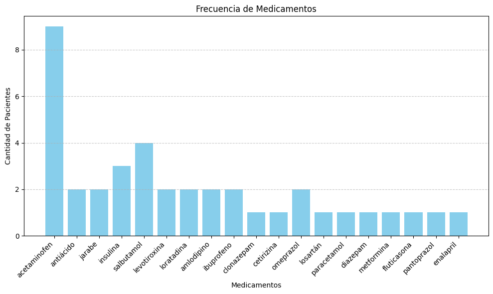

```python
# Listas para almacenar los medicamentos y sus frecuencias
#medicamentos = []
#frecuencias = []

# Carga y lectura de datos clinica.json

import json

choise = input('Por favor ingrese la base de datos: 1 = Clínica Intermedia, 2 = Clínica')

bd = []

if choise in '1':
    bd = 'clinica_intermedio.json'
else:
    bd = 'clinica.json'

with open(bd, encoding='utf-8') as archivo:
    datos_pacientes = json.load(archivo)

#Creación de listas

medicamentos = []
frecuencias = []
med = []

for listas in datos_pacientes:
    med.append(listas[5])

#Lista de enfermedades únicas y lista de conteo de cada enfermedad

for i in med:
    if i in medicamentos:

        indice = medicamentos.index(i)
        frecuencias[indice] += 1

    else:
        medicamentos.append(i)
        frecuencias.append(1)

#Impresión del reporte

print(f"{'Medicamento':<20} {' '} {'Cantidad de Pacientes'}")
print("-" * 45)

for med, cantidad in zip(medicamentos, frecuencias):
    print(f"{med:<20} {'|'} {'         '} {cantidad}")
    print("-" * 45)

total = sum(frecuencias)

print(f"{'Total':<20} {'|'} {'         '} {total}")
print("-" * 45)

# Crear gráfico de barras
plt.figure(figsize=(10, 6))
plt.bar(medicamentos, frecuencias, color='skyblue')
plt.xlabel('Medicamentos')
plt.ylabel('Cantidad de Pacientes')
plt.title('Frecuencia de Medicamentos')
plt.xticks(rotation=45, ha='right')  # Rotar etiquetas para mejor visibilidad
plt.grid(axis='y', linestyle='--', alpha=0.7)
plt.tight_layout()  # Ajustar el espacio para evitar superposición
plt.show()
```

### Respuesta a las Preguntas:

- ¿Qué medicamentos son los más recetados?

R/ El top 3 de medicamento srecetados es:

1. Acetaminofen
2. Salbutamol
3. Insulina
- ¿Cómo podrías optimizar el uso de medicamentos en la clínica?

R/ Teniendo un stock de medicamentos acorde a la demanda vista en el reporte, de manera tal que se tenga una reserva adecuada de los medicamentos que conforman el top 5 de la lista.

## Desafío 3: Ingeniería - Comparar Pacientes por Identificación

Este desafío te permitirá comparar dos pacientes de la clínica en base a sus identificaciones. Tu objetivo es averiguar:

1. **¿Qué enfermedades tienen en común?**
2. **¿Qué medicamentos toman en común?**

### Instrucciones:

1. Solicita dos identificaciones de pacientes al usuario.
2. Extrae las enfermedades y medicamentos de esos dos pacientes.
3. Compara las enfermedades y medicamentos y muestra los resultados.

### Preguntas:

- ¿Qué enfermedades y medicamentos son comunes en los pacientes comparados?
- ¿Qué información adicional podrías incluir para mejorar esta comparación?

```python
# Pedimos las identificaciones de los dos pacientes
id_paciente1 = input("Ingrese la identificación del primer paciente: ")
id_paciente2 = input("Ingrese la identificación del segundo paciente: ")

# Función para buscar al paciente por identificación
def buscar_paciente(id_paciente):
    for paciente in datos_pacientes:
        if paciente[0] == id_paciente:
            return paciente
    return None


# Buscar los registros de los pacientes
paciente1 = buscar_paciente(id_paciente1)
paciente2 = buscar_paciente(id_paciente2)

try:

    #Impresión del reporte

    print(f"{'Paciente':<13} {'|'} {'Enfermedad':<13} {'|'} {'Medicamento':<13}")
    print("-" * 45)
    print(f"{paciente1[0]:<13} {'|'} {paciente1[4]:<13} {'|'} {paciente1[5]:<13}")
    print("-" * 45)
    print(f"{paciente2[0]:<13} {'|'} {paciente2[4]:<13} {'|'} {paciente2[5]:<13}")
    print("-" * 45)


    # Verificar si ambos pacientes existen en los datos
    print('\nResumen Pacientes:')
    print("-" * 18)

    #Comparación
    if paciente1 and paciente2:

        # Comparación enfermedad
        if paciente1[4] == paciente2[4]:
            print("\n* Ambos pacientes tienen la misma enfermedad.")
        else:
            print("\n* Los pacientes tienen enfermedades diferentes.")

        # Comparación medicamentos
        if paciente1[5] == paciente2[5]:
            print("\n* Ambos pacientes están tomando el mismo medicamento.")
        else:
            print("\n* Los pacientes están tomando medicamentos diferentes.")
    else:
        print("\nUno o ambos pacientes no se encontraron en la base de datos.")

except ValueError as ve:
    print(f"\nError: {ve}")

except Exception as e:
    print(f"\nOcurrió un error inesperado: {e}")

#"""
#Prueba con 702370234 - 215487963
#Salida esperada
#Enfermedades en común entre 702370234 y 215487963: ['migraña']
#Medicamentos en común entre 702370234 y 215487963: ['acetaminofen']
#"""
```

```
Paciente      | Enfermedad    | Medicamento
---------------------------------------------
215487963     | migraña       | acetaminofen
---------------------------------------------
702370234     | migraña       | acetaminofen
---------------------------------------------

Resumen Pacientes:
------------------

* Ambos pacientes tienen la misma enfermedad.

* Ambos pacientes están tomando el mismo medicamento.
```

## Desafío Final: Arte y Matemáticas - Visualización Creativa y Reflexión

Has llegado al último desafío, ¡felicidades! Ahora es momento de presentar tus resultados de una forma creativa. Tu tarea será utilizar **gráficos**, **tablas** o incluso **arte digital** para mostrar tus descubrimientos sobre los datos de los pacientes de la clínica.

### Preguntas:

- ¿Qué patrones encontraste en los datos?
- ¿Cómo podrías usar estos análisis para mejorar la atención de los pacientes?

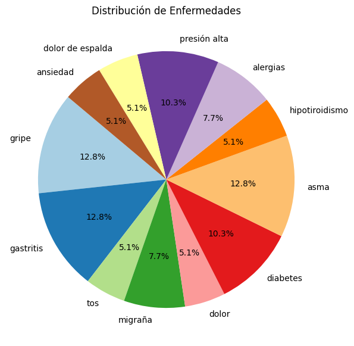

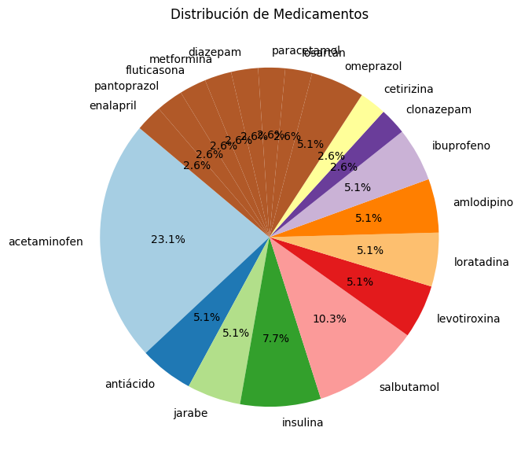

```
--------------------------------------------------
La provincia con más personas enfermas es: San José
Cantidad de pacientes: 9
--------------------------------------------------

Detalle del conteo por provincia:
San José        | 9
Heredia         | 6
Alajuela        | 3
Cartago         | 6
Puntarenas      | 5
Guanacaste      | 5
Limón           | 5
```

```python
#Gráfico de pie enfermedades
plt.figure(figsize=(10, 7))
plt.pie(lista_cantidades, labels=lista_enfermedades, autopct='%1.1f%%', startangle=140, colors=plt.cm.Paired(range(len(lista_enfermedades))))
plt.title('Distribución de Enfermedades')
plt.show()

#Gráfico de pie medicamentos.
plt.figure(figsize=(10, 7))
plt.pie(frecuencias, labels=medicamentos, autopct='%1.1f%%', startangle=140, colors=plt.cm.Paired(range(len(medicamentos))))
plt.title('Distribución de Medicamentos')
plt.show()

import json

# Elegir la base de datos
choise = input('Por favor ingrese la base de datos: 1 = Clínica Intermedia, 2 = Clínica')

bd = []

if choise == '1':
    bd = 'clinica_intermedio.json'
else:
    bd = 'clinica.json'

# Cargar datos del archivo JSON
with open(bd, encoding='utf-8') as archivo:
    datos_pacientes = json.load(archivo)

# Crear un diccionario para contar pacientes por provincia
conteo_provincias = {}

for paciente in datos_pacientes:
    provincia = paciente[2]  # Índice 2 corresponde a la provincia

    # Si la provincia ya está en el diccionario, sumar 1
    if provincia in conteo_provincias:
        conteo_provincias[provincia] += 1
    else:
        conteo_provincias[provincia] = 1

# Encontrar la provincia con el máximo de pacientes
provincia_max = max(conteo_provincias, key=conteo_provincias.get)
cantidad_max = conteo_provincias[provincia_max]

# Imprimir el resultado
print("\n" + "-" * 50)
print(f"La provincia con más personas enfermas es: {provincia_max}")
print(f"Cantidad de pacientes: {cantidad_max}")
print("-" * 50)

# Imprimir el detalle del conteo por provincia
print("\nDetalle del conteo por provincia:")
for provincia, cantidad in conteo_provincias.items():
    print(f"{provincia:<15} | {cantidad}")
```

### Respuesta Preguntas:

- ¿Qué patrones encontraste en los datos?

R/ Basado en la vista del gráfico de barras con respecto a los medicamentos suministrados, se puede observar que lo más común es una relación de 1 a 1 (Un medicamento una persona) en pacientes y medicamentos, seguido por una relación de 1 a 2 (Un medicamento dos personas). Adicionalmente se puede observar que el medicamento con más demanda es la acetaminofen.

En cuanto a tipos de enfermedades la muestra indica que los tres padecimientos más comunes (Padecidos y tratados) son la gripe, la gastritis y el asma con un 12.8% para cada enfermedad; lo que equivale a decir que el 38.4% de los pacientes padecen alguna de estas tres enfermedades.

- ¿Cómo podrías usar estos análisis para mejorar la atención de los pacientes?

R/ En cuanto a los medicamentos, se podría obtimizar el inventario de los mismos basados en la frecuencia de las recetas según la muestra. Por otra parte se puede capacitar a los médicos en el tratamientos de las enfermedades cronicas más comunes (Se excluye la gripe) según la estadistica: asma, gastritis y diabetes ya que estás mal tratadas pueden conducir a la muerte. Por ultimo se posible valorar el esfuerzo y los recursos asignados a cada provincia de acuerdo al cuadro resumen que muestra los enfermos por provisia, en donde se puede apreciar que San José es la provincia con más pacientes (9).